# Practical Machine Learning Course Project

Clay Girdner

3/16/2020

# Predicting Workout Effectiveness

## Objective

The goal of this analysis is to predict the manner in which a given exercise was performed by a select group of test subjects.

## Data

Before we get too far, let’s first load the libraries we will need.

```r
library(caret)
library(parallel)
library(doParallel)
```

Data for this project comes from the Human Activity Recognition dataset available here: http://groupware.les.inf.puc-rio.br/har. With the data downloaded, we can now read it into R.

```r
training <- read.csv("pml-training.csv", na.strings = c("#DIV/0!", "NA"))
testing  <- read.csv("pml-testing.csv", na.strings = c("#DIV/0!", "NA"))

dim(training)
```

```
## [1] 19622   160
```

```r
dim(testing)
```

```
## [1]  20 160
```

The variable we are concerned with in this analysis is the *classe* variable which describes how the exercise in question was performed. Rows with a *classe* value of “A” indicate a properly performed excercise, while “B”, “C”, “D”, and “E” represent different mistakes which occured during the exercise.

```r
summary(training$classe)
```

```
##    A    B    C    D    E
## 5580 3797 3422 3216 3607
```

If we want a machine learning model, we first need to train/test it on a subset of our training data. In this case we will split it 70/30 training to test data.

```r
# partition the training dataset
set.seed(123)
inTrain  <- createDataPartition(training$classe, p=0.7, list=FALSE)
trainSub <- training[inTrain, ]
testSub  <- training[-inTrain, ]

dim(trainSub)
```

```
## [1] 13737   160
```

```r
dim(testSub)
```

```
## [1] 5885  160
```

Now we need to do a little data processing/cleaning before we can proceed. First, we will remove the initial seven columns of data, as these just represent ID fields such as name and time. Then we will look for variables with nearly zero variance (NZV), and drop these columns. Lastly, we will scan for columns with a large percentage of NA values and remove them.

```r
# remove ID data fields (first 7 columns)
trainSub <- trainSub[, -c(1:7)]
testSub  <- testSub[, -c(1:7)]

# remove variables with nearly zero variance (NZV)
NZV <- nearZeroVar(trainSub)
trainSub <- trainSub[, -NZV]
testSub  <- testSub[, -NZV]

# remove variables with more than 75% NA values (NAs)
# (47 of the variables are 98% NA values)
NAs <- sapply(trainSub, function(x) mean(is.na(x))) > 0.75
trainSub <- trainSub[, NAs == FALSE]
testSub  <- testSub[, NAs == FALSE]

dim(trainSub)
```

```
## [1] 13737    53
```

```r
dim(testSub)
```

```
## [1] 5885   53
```

# Model Testing and Selection

With our data now clean, we can now start training some models. We chose to compare two different forms of ensemble models - random forest (rf) and gradient boosting machine (gbm). We also chose to perform cross validation while building these models as it helps reduce error (both in and out of sample). In this case, we opted for 5 fold validation. The last piece we should mention is the inclustion of parallel processing which greatly helped to speed up the model training process.

```r
# configure parallel processing
cluster <- makeCluster(detectCores() - 1)
registerDoParallel(cluster)

# standard 5-fold cross validation (CV)
fitControl <- trainControl(method = "cv", number = 5, allowParallel = TRUE)

# train random forest model on trainSub data
fit_rf <- train(classe ~ ., data = trainSub, method="rf",
                trControl = fitControl, verbose = FALSE)

# train gradient boosting model on trainSub data
fit_gbm <- train(classe ~ ., data = trainSub, method="gbm",
                trControl = fitControl, verbose = FALSE)

# de-register parallel processing cluster
stopCluster(cluster)
registerDoSEQ()
```

```r
# model predictions
pred_rf <- predict(fit_rf, newdata = testSub)
pred_gbm <- predict(fit_gbm, newdata = testSub)
```

```r
confusionMatrix(testSub$classe, pred_rf)$overall[1]
```

```
##  Accuracy
## 0.9937128
```

```r
confusionMatrix(testSub$classe, pred_gbm)$overall[1]
```

```
##  Accuracy
## 0.9639762
```

Although both methods seem to provide impressive results (rf accuracy = 99%, gbm accuracy = 96%), the random forest model wins in this matchup and will be used for the remainder of this analysis.

We know that the random forest model was accurate, but now let’s take a look at some its other attributes.

```r
fit_rf
```

```
## Random Forest
##
## 13737 samples
##    52 predictor
##     5 classes: 'A', 'B', 'C', 'D', 'E'
##
## No pre-processing
## Resampling: Cross-Validated (5 fold)
## Summary of sample sizes: 10990, 10990, 10989, 10988, 10991
## Resampling results across tuning parameters:
##
##   mtry  Accuracy   Kappa
##    2    0.9914103  0.9891333
##   27    0.9910464  0.9886736
##   52    0.9848584  0.9808444
##
## Accuracy was used to select the optimal model using the largest value.
## The final value used for the model was mtry = 2.
```

If in-sample accuracy = 0.9914103, then the in-sample error rate = 0.0085897 (1 - accuracy). Now let’s look at out-of-sample error.

```r
confusionMatrix(testSub$classe, pred_rf)
```

```
## Confusion Matrix and Statistics
##
##           Reference
## Prediction    A    B    C    D    E
##          A 1674    0    0    0    0
##          B    4 1131    4    0    0
##          C    0    5 1021    0    0
##          D    0    0   14  950    0
##          E    1    0    5    4 1072
##
## Overall Statistics
##
##                Accuracy : 0.9937
##                  95% CI : (0.9913, 0.9956)
##     No Information Rate : 0.2853
##     P-Value [Acc > NIR] : < 2.2e-16
##
##                   Kappa : 0.992
##
##  Mcnemar's Test P-Value : NA
##
## Statistics by Class:
##
##                      Class: A Class: B Class: C Class: D Class: E
## Sensitivity            0.9970   0.9956   0.9780   0.9958   1.0000
## Specificity            1.0000   0.9983   0.9990   0.9972   0.9979
## Pos Pred Value         1.0000   0.9930   0.9951   0.9855   0.9908
## Neg Pred Value         0.9988   0.9989   0.9953   0.9992   1.0000
## Prevalence             0.2853   0.1930   0.1774   0.1621   0.1822
## Detection Rate         0.2845   0.1922   0.1735   0.1614   0.1822
## Detection Prevalence   0.2845   0.1935   0.1743   0.1638   0.1839
## Balanced Accuracy      0.9985   0.9970   0.9885   0.9965   0.9990
```

If you’re smart, you probably already knew what the out-of-sample error was by using the accuracy value listed above when we were comparing rf and gbm. We obtain the out-of-sample error rate by taking the accuracy when predicting on the test data (0.9937) and subtracting it from one. This gives us a error value of 0.0063, which is actually less than the in-sample error rate, indicating this is a pretty strong model.

# Final Model

The next move is to retrain our random forest model on the entirety of the training data (more data is better than less data). However, before we can do this we need to reclean the training data as we did in the inital training phase.

```r
# remove ID data fields (first 7 columns)
training <- training[, -c(1:7)]
testing  <- testing[, -c(1:7)]

# remove variables with nearly zero variance (NZV)
NZV <- nearZeroVar(training)
training <- training[, -NZV]
testing  <- testing[, -NZV]

# remove variables with more than 75% NA values (NAs)
# (47 of the variables are 98% NA values)
NAs <- sapply(training, function(x) mean(is.na(x))) > 0.75
training <- training[, NAs == FALSE]
testing  <- testing[, NAs == FALSE]

dim(training)
```

```
## [1] 19622    53
```

```r
dim(testing)
```

```
## [1] 20 53
```

With the data properly cleaned, we can now fit the random forest model on the training data in the same manner we did before.

```r
# configure parallel processing
cluster <- makeCluster(detectCores() - 1)
registerDoParallel(cluster)

# train random forest model on training data
fit_final <- train(classe ~ ., data = training, method="rf",
                   trControl = fitControl, verbose = FALSE)

# de-register parallel processing cluster
stopCluster(cluster)
registerDoSEQ()

fit_final
```

```
## Random Forest
##
## 19622 samples
##    52 predictor
##     5 classes: 'A', 'B', 'C', 'D', 'E'
##
## No pre-processing
## Resampling: Cross-Validated (5 fold)
## Summary of sample sizes: 15699, 15696, 15699, 15697, 15697
## Resampling results across tuning parameters:
##
##   mtry  Accuracy   Kappa
##    2    0.9939859  0.9923915
##   27    0.9940370  0.9924565
##   52    0.9889406  0.9860086
##
## Accuracy was used to select the optimal model using the largest value.
## The final value used for the model was mtry = 27.
```

```r
var_imp <- varImp(fit_final, scale = FALSE)
var_imp
```

```
## rf variable importance
##
##   only 20 most important variables shown (out of 52)
##
##                      Overall
## roll_belt             2019.1
## pitch_forearm         1225.7
## yaw_belt              1138.8
## pitch_belt             940.9
## roll_forearm           912.0
## magnet_dumbbell_y      901.2
## magnet_dumbbell_z      880.0
## accel_dumbbell_y       476.9
## accel_forearm_x        378.7
## roll_dumbbell          357.3
## magnet_dumbbell_x      349.6
## accel_dumbbell_z       318.5
## accel_belt_z           314.5
## magnet_forearm_z       310.0
## magnet_belt_z          309.1
## total_accel_dumbbell   303.1
## magnet_belt_y          293.6
## gyros_belt_z           261.4
## yaw_arm                255.7
## magnet_belt_x          223.9
```

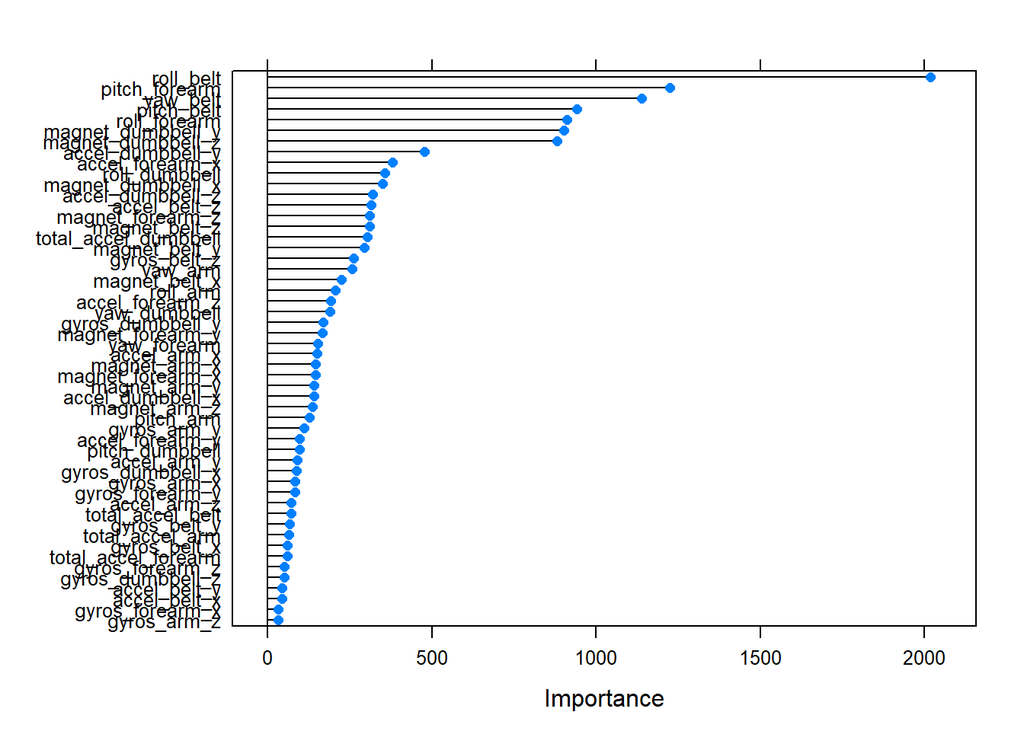

```r
plot(var_imp)
```

Again, we see very good accuracy (>99%), which is encouraging. I’ve also included a plot displaying the importance of each variable. It appears that movement around the belt area is highly important when predicting quality of this particular exercise as three of the top five variables are related to the belt measurement.

The last step in this analysis is to predict the 20 testing observations using final random forest model. Results are below.

```r
final_preds <- predict(fit_final, newdata = testing)
final_preds
```

```
##  [1] B A B A A E D B A A B C B A E E A B B B
## Levels: A B C D E
```